# Introduction

# Price of the fleet

```
The average cost: 100.8
The total fleet: 30
The total cost: 3024.0 million $
```

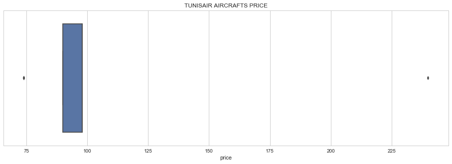

```python
fig = plt.figure(figsize=(16,5))
sns.set_style("whitegrid")
ax = sns.boxplot(x=tt["price"]).set_title('TUNISAIR AIRCRAFTS PRICE')
print("The average cost:",tt["price"].mean())
print("The total fleet:",tt["price"].count())
print("The total cost:",tt["price"].sum(),'million $')
```

```
The average cost: 103.45283018867924
The total fleet: 53
The total cost: 5483.0 million $
```

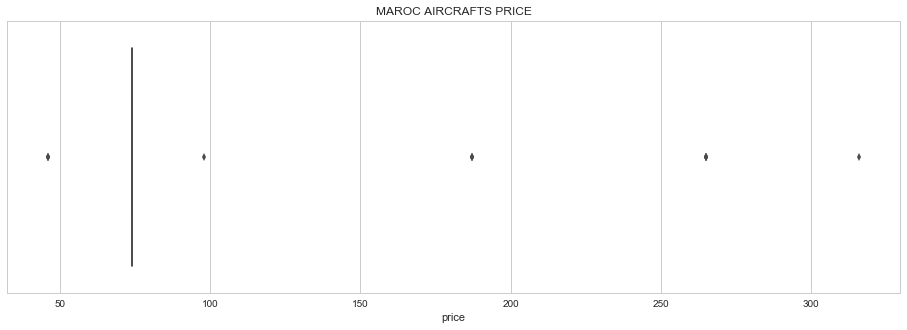

```python
fig = plt.figure(figsize=(16,5))
sns.set_style("whitegrid")
ax = sns.boxplot(x=maroc["price"]).set_title('MAROC AIRCRAFTS PRICE')
print("The average cost:",maroc["price"].mean())
print("The total fleet:",maroc["price"].count())
print("The total cost:",maroc["price"].sum(),'million $')
```

```
The average cost: 143.80357142857142
The total fleet: 56
The total cost: 8053.0 million $
```

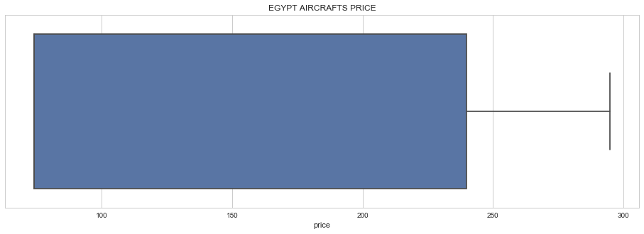

```python
fig = plt.figure(figsize=(16,5))
sns.set_style("whitegrid")
ax = sns.boxplot(x=egypt["price"]).set_title('EGYPT AIRCRAFTS PRICE')
print("The average cost:",egypt["price"].mean())
print("The total fleet:",egypt["price"].count())
print("The total cost:",egypt["price"].sum(),'million $')
```

The average cost of Tunisair' fleet is the lowest compared to MAROC AIRCRAFTS and EGYPT AIRCRAFTS  
We notice that the total price cost of the fleet for each airline depends on the size of it  
So we are going to analyse the size of the different fleets

# Size of the fleet

```python
frames = [tt,maroc,egypt,MauritiusAilines,SouthAfricanAirways,NigeriaAilines,EthiopianAirlines,AirAlgerie]
result = pd.concat(frames)
result=result[['Reg', 'AircraftType', 'config','delivered',
                                        'Age','Airline']]
```

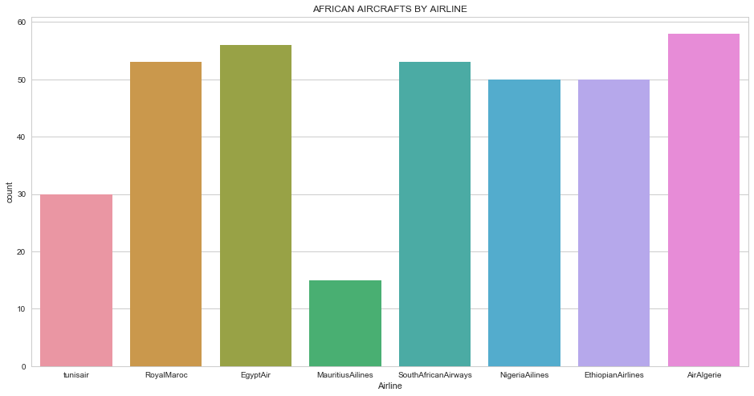

```python
fig = plt.figure(figsize=(16,8))
ax = sns.countplot(x='Airline',data=result).set_title('AFRICAN AIRCRAFTS BY AIRLINE')
```

AlgeriaAirline has the biggest size of the fleet and yet isn't the first airline in the african market which means that the size of the fleet isn’t the only factor to dominate such a market.  
Tunisair's fleet size is modest compared to other fleets compared to other fleets To sum up the size of Tunisair's fleet is not considered as a weakness at this point

```python
ech=dd.loc[dd['Airline'] != "tunisair"]
mech=ech['Age'].mean()
tt=dd.loc[dd['Airline'] == "tunisair"]
ttm=tt['Age'].mean()
```

```python
age = []
price=[]
for e in dd['Age']:
    age.append(float(e))
dd['Age']=age
for e in dd['price']:
    price.append(float(e))
dd['price']=price
```

# Internationl Aircrafts types

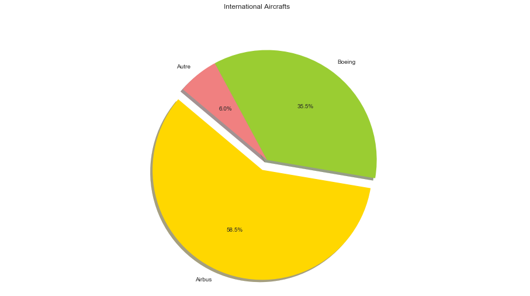

```python
labels = 'Airbus', 'Boeing', 'Autre'
sizes = [len(air),len(boe),len(autres)]
colors = ['gold', 'yellowgreen', 'lightcoral', 'lightskyblue']
explode = (0.1, 0, 0)  # explode 1st slice
fig = plt.figure(figsize=(16,8))
fig.suptitle('International Aircrafts')
# Plot
plt.pie(sizes, explode=explode, labels=labels, colors=colors,
        autopct='%1.1f%%', shadow=True, startangle=140)

plt.axis('equal')
plt.show()
```

The most requested aircrafts types all around the world are:

> Airbus and Boeing

```python
air=[]
boe=[]
autres=[]
for index, row in dd.iterrows():
        if("Airbus" in row['AircraftType']):
            air.append(row['AircraftType'])
        elif("Boeing" in row['AircraftType']):
            boe.append(row['AircraftType'])
        else:
            autres.append(row['AircraftType'])
```

```python
airtt=[]
boett=[]
autrestt=[]
for index, row in tt.iterrows():
        if("Airbus" in row['AircraftType']):
            airtt.append(row['AircraftType'])
        elif("Boeing" in row['AircraftType']):
            boett.append(row['AircraftType'])
        else:
            autrestt.append(row['AircraftType'])
```

# Tunisair Aircrafts types

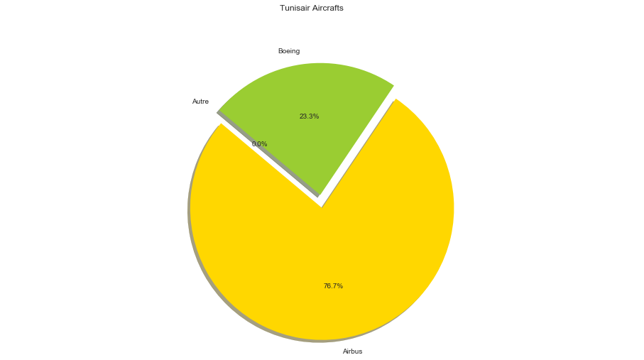

```python
labels = 'Airbus', 'Boeing', 'Autre'
sizes = [len(airtt),len(boett),len(autrestt)]
colors = ['gold', 'yellowgreen', 'lightcoral', 'lightskyblue']
explode = (0.1, 0, 0)  # explode 1st slice
fig = plt.figure(figsize=(16,8))
fig.suptitle('Tunisair Aircrafts')
# Plot
plt.pie(sizes, explode=explode, labels=labels, colors=colors,
        autopct='%1.1f%%', shadow=True, startangle=140)

plt.axis('equal')
plt.show()
```

Most of Tunisair's aircrafts type are Airbus  
At this point we can not judge wether Tunisair's fleet is similar to the international fleet profile since Airbus contains many models, so we will detail this point later

# Competitors of Tunisair in the African market

```python
airm=[]
boem=[]
autresm=[]
for index, row in maroc.iterrows():
        if("Airbus" in row['AircraftType']):
            airm.append(row['AircraftType'])
        elif("Boeing" in row['AircraftType']):
            boem.append(row['AircraftType'])
        else:
            autresm.append(row['AircraftType'])
```